← Back to RTM-Suite

# ToolsRTM — Complete Reference Manual

Every model, every algorithm option, explained and verified by real execution

2026-08-20

# What this manual is

Every function call below actually runs against the real package — nothing here is illustrative pseudocode. Where a step needs external software (Python/TensorFlow for deep learning), that’s stated explicitly, with real setup instructions, not glossed over.

```r
library(ToolsRTM)
```

# Leaf models — what’s really available

| `leaf.model` value | What it is | Parameters it needs (in `inputLUT`) |
| --- | --- | --- |
| `"PROSPECT-PRO"` | Leaf optical model with separate protein (Prot) and carbon-based constituent (CBC) pools instead of one lumped dry-matter term | N, Cab, Car, Anth, Cbrown, EWT, LMA, alpha, Prot, CBC |
| `"PROSPECT-D"` | Leaf optical model with anthocyanins (Anth) added to the classic PROSPECT structure | N, Cab, Car, Anth, Cbrown, EWT, LMA, alpha |
| `"Liberty"` | Alternative leaf model for coniferous/needle leaves, using a different scattering formulation than PROSPECT | see `?liberty` |
| `"Fluspect-B"` | PROSPECT-family model extended to also simulate chlorophyll fluorescence emission | Cab, Cdm, Cw, Cs, Cca, N (via `inputsLeaf`) |
| `"Fluspect-B-Cx"` | Fluspect-B variant that also accounts for the xanthophyll (Cx) de-epoxidation state, relevant for PRI (Photochemical Reflectance Index) studies | as Fluspect-B, plus Cx |

# Canopy models — what’s really available

There are exactly **three** independent canopy models in this package. Everything else you might see referenced internally (`foursail.inform`, `foursail.inf`, `foursail_t_o`, `foursail_t_s`) are implementation details `INFORM` uses internally — not standalone models you call directly.

[output not shown]

`simulate_RTM()` is the single dispatcher that connects any leaf model to any of these three canopy models, handling the plumbing. It errors clearly instead of silently producing wrong results for an unsupported name.

```r
inputs <- ToolsRTM::inputsPROSAIL
LUT <- as.data.frame(ToolsRTM::getLUT(inputs = inputs, nLUT = 30, setseed = 1234))
rsoil <- rep(0.2, 2101)

# fourSAIL — runs for real
sim <- simulate_RTM(inputLUT = LUT[1, ], rsoil = rsoil,
                     leaf.model = "PROSPECT-PRO", canopy.model = "fourSAIL")
cat("fourSAIL succeeded, returned", length(sim), "reflectance components.\n")
```

```
## fourSAIL succeeded, returned 4 reflectance components.
```

```r
# foursail2 — needs the extra green/brown-vegetation columns first
LUT2 <- LUT
LUT2$fraction_brown <- 0.2; LUT2$diss <- 0.5; LUT2$Cv <- 0.8; LUT2$Zeta <- 1.2
sim2 <- simulate_RTM(inputLUT = LUT2[1, ], rsoil = rsoil, canopy.model = "foursail2",
                      PROSPECTversion = "PRO")
cat("foursail2 succeeded, returned", length(sim2), "elements.\n")
```

```
## foursail2 succeeded, returned 6 elements.
```

```r
# An unknown name — errors clearly instead of guessing
result <- tryCatch(
  simulate_RTM(inputLUT = LUT[1, ], rsoil = rsoil, canopy.model = "fourSAIL-inf"),
  error = function(e) conditionMessage(e)
)
cat("Attempted unsupported name ->", result, "\n")
```

```
## Attempted unsupported name -> Unknown canopy.model: 'fourSAIL-inf'. This package has exactly three real canopy models: 'fourSAIL', 'foursail2', 'INFORM'. (foursail.inform/foursail.inf/foursail_t_o/foursail_t_s are internal helpers INFORM uses, not standalone options.)
```

fourSAIL and foursail2 both ran for real, and the deliberately-wrong canopy name failed with a clear error instead of a silent wrong result — `simulate_RTM()` is meant to be the single entry point regardless of which leaf/canopy combination you pick.

# Building a LUT: distribution and correlation options

`getLUT()` (used above) samples parameters independently. Two functions give more control:

## `get.LUTfromRanges()` — choose the sampling distribution

```r
# LUT.range: your own data.frame with columns (input, min, max) — the
# parameter names must match what your chosen leaf/canopy model expects.
LUT.range <- data.frame(
  input = c("N", "Cab", "Car", "Cbrown", "EWT", "LMA"),
  min   = c(1.0,  10,    2,     0,        0.005, 0.005),
  max   = c(3.0,  80,    25,    1,        0.030, 0.030)
)

lut_uniform <- get.LUTfromRanges(LUT = LUT.range, nLUT = 50, setseed = 1,
                                  leaf.model = "PROSPECT-D", canopy.model = "fourSAILH",
                                  distribution = "uniform")
lut_gauss   <- get.LUTfromRanges(LUT = LUT.range, nLUT = 50, setseed = 1,
                                  leaf.model = "PROSPECT-D", canopy.model = "fourSAILH",
                                  distribution = "gauss")
cat("Uniform Cab range: [", round(min(lut_uniform$Cab),1), ",", round(max(lut_uniform$Cab),1), "]\n")
```

```
## Uniform Cab range: [ 12.3 , 76.5 ]
```

```r
cat("Gauss Cab range:   [", round(min(lut_gauss$Cab),1), ",", round(max(lut_gauss$Cab),1), "] (concentrated toward the middle)\n")
```

```
## Gauss Cab range:   [ 9.9 , 71.4 ] (concentrated toward the middle)
```

`distribution = "uniform"` spreads samples evenly across `[min, max]`. `distribution = "gauss"` concentrates them around the range’s midpoint — use this when you want most simulated plants to look “typical”, with fewer extreme trait combinations, instead of every value in the range being equally likely.

## `getCor()` — sample correlated traits instead of independent ones

Real leaf/canopy traits aren’t independent (e.g. Cab and N tend to co-vary). `getCor()` generates a correlated LUT instead of treating every parameter as unrelated to the others.

```r
cor_result <- suppressMessages(invisible(capture.output(
  cor_lut <- getCor(n_inputs = 2, nLUT = 200, distribution = "Normal", setseed = 1,
                     rho = 0.7, Varnames = c("Cab", "LAI"),
                     MinRange = c(10, 0.5), MaxRange = c(80, 7))
)))
cat("Correlation actually achieved between Cab and LAI:",
    round(cor(cor_lut$LUT$Cab, cor_lut$LUT$LAI), 2), "\n")
```

```
## Correlation actually achieved between Cab and LAI: 0.7
```

`getCor()` returns a list: `$LUT` (the correlated parameter table you actually use) and `$Covarianza` (the covariance matrix behind it, for reference).

`distribution` here accepts `"Normal"` or `"Uniform"` (note: capitalized differently from `get.LUTfromRanges()`’s `"uniform"`/`"gauss"` — a real inconsistency in the package worth knowing about, not something to guess past). `rho` is the target correlation coefficient between the two traits.

# Convolving to a real sensor

`get.spectra.convolved()` supports these sensors right now:

| `sensor` value | What it is |
| --- | --- |
| `"Sentinel2a"` | ESA Sentinel-2A MultiSpectral Instrument, 13 bands |
| `"Sentinel2b"` | ESA Sentinel-2B MultiSpectral Instrument, 13 bands (near-identical to 2A) |
| `"PRISMA"` | Italian Space Agency hyperspectral mission, ~230+ narrow bands |

```r
wl <- seq(400, 2500, length.out = 2101)
brf <- Compute_BRF(rdot = sim[[1]], rsot = sim[[2]], tts = LUT[1, "tts"],
                    data.light = ToolsRTM::dataSpec_PDB)
sim.matrix <- matrix(brf, nrow = 1)
colnames(sim.matrix) <- paste0("X", round(wl))

invisible(capture.output({
  s2a <- get.spectra.convolved(rfl = sim.matrix, sensor = "Sentinel2a", plot.spectra = FALSE)
  prisma <- get.spectra.convolved(rfl = sim.matrix, sensor = "PRISMA", plot.spectra = FALSE)
}))
cat("Sentinel-2A gives", ncol(s2a) - 1, "bands. PRISMA gives", ncol(prisma) - 1, "bands.\n")
```

```
## Sentinel-2A gives 13 bands. PRISMA gives 234 bands.
```

Same native 1nm spectrum, two different sensors: Sentinel-2A’s 13 multispectral bands vs. PRISMA’s 230+ narrow hyperspectral bands — pick whichever matches the real sensor your own reflectance data comes from.

# Vegetation indices

`get.indices.v2()` computes the common vegetation indices directly from a simulated or convolved spectrum – here’s a handful of them for the single spectrum simulated above, rounded to 3 decimals for readability:

```r
idx <- get.indices.v2(as.data.frame(sim.matrix), pattern.rfl = "X", spectral.domain = "VNIR")
```

[output not shown]

```r
knitr::kable(round(idx[, 1:6], 3))
```

|  | x |
| --- | --- |
| NDVI | 0.841 |
| RDVI | 0.445 |
| SR | 11.576 |
| MSR | 2.402 |
| OSAVI | 0.621 |
| MSAVI | 0.437 |

# Inversion: all 12 algorithms, and what each is actually for

`get.inversion()` isn’t just Random Forest — it wraps 12 real, distinct algorithms via `caret`:

| `algorithm` | Family | When you’d pick it |
| --- | --- | --- |
| `"PLSR"` | Partial Least Squares Regression | Classic choice for spectra — handles many correlated predictor bands well |
| `"SVM"` | Support Vector Machine | Good with fewer, well-chosen predictors (e.g. after `getVIF()`) |
| `"RF"` | Random Forest | Robust default, handles nonlinearity, less sensitive to outliers |
| `"GB"` | Gradient Boosting | Often more accurate than RF, more prone to overfitting on small datasets |
| `"NN"` | (Shallow) Neural Network | Nonlinear, needs more data than PLSR/RF to be reliable |
| `"Bayesian"` | Bayesian regression | Gives uncertainty estimates alongside predictions |
| `"AdaBag"` | Bagged AdaBoost | Ensemble method, robust to noisy training data |
| `"BRNN"` | Bayesian Regularized Neural Network | Neural net with built-in regularization — less prone to overfitting than plain NN |
| `"xGB"` | Extreme Gradient Boosting | Usually the strongest “classic ML” option, more hyperparameters to tune |
| `"RVM"` | Relevance Vector Machine | Like SVM but sparser and probabilistic |
| `"qLASSO"` | Quantile LASSO | Regression with built-in variable selection |
| `"Ensemble"` | Combination of the above | When you want to average out individual model weaknesses |

```r
# Real inversion needs more samples than the nLUT=30 demo above — with too
# few samples, PLSR's automatic component-count tuning can ask for more
# components than the data can support. 150 is still small for production
# use (thousands is common), but enough for this manual to run cleanly.
LUT_inv <- as.data.frame(ToolsRTM::getLUT(inputs = inputs, nLUT = 150, setseed = 99))
n <- nrow(LUT_inv)
all_brf <- matrix(NA, nrow = n, ncol = length(brf))
invisible(capture.output({
  for (i in seq_len(n)) {
    s <- foursail(inputLUT = LUT_inv[i, ], rsoil = rsoil, LeafModel = "PROSPECT-PRO")
    all_brf[i, ] <- Compute_BRF(rdot = s[[1]], rsot = s[[2]], tts = LUT_inv[i, "tts"], data.light = ToolsRTM::dataSpec_PDB)
  }
}))
colnames(all_brf) <- paste0("X", round(wl))
train_df <- data.frame(all_brf); train_df$LAI <- LUT_inv$LAI

inv_rf <- get.inversion(data = train_df, depVar = "LAI", inputs = colnames(all_brf),
                         algorithm = "RF", n.samples = nrow(train_df), seed = 42)
```

```
## [1] "processing hybrid approach using Random Forest ..."
## -0.01305656 0.01
## -0.02891583 0.01
```

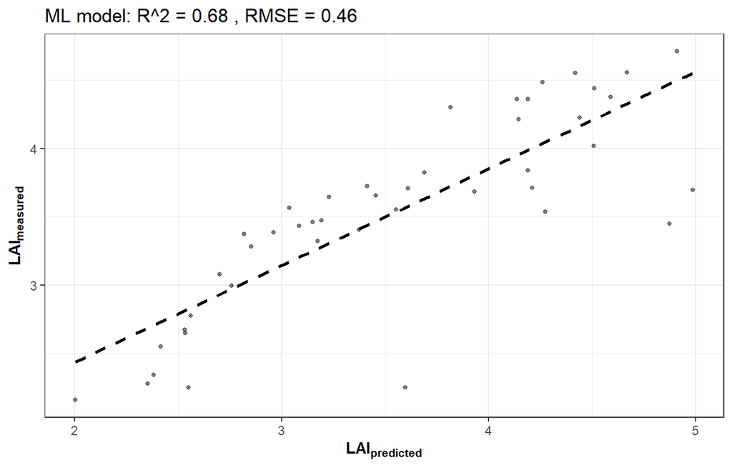

```r
cat("RF inversion trained. Object class:", class(inv_rf)[1], "\n")
```

```
## RF inversion trained. Object class: list
```

```r
inv_plsr <- get.inversion(data = train_df, depVar = "LAI", inputs = colnames(all_brf),
                           algorithm = "PLSR", n.samples = nrow(train_df), seed = 42)
```

```
## [1] "processing hybrid approach using PLSR ..."
```

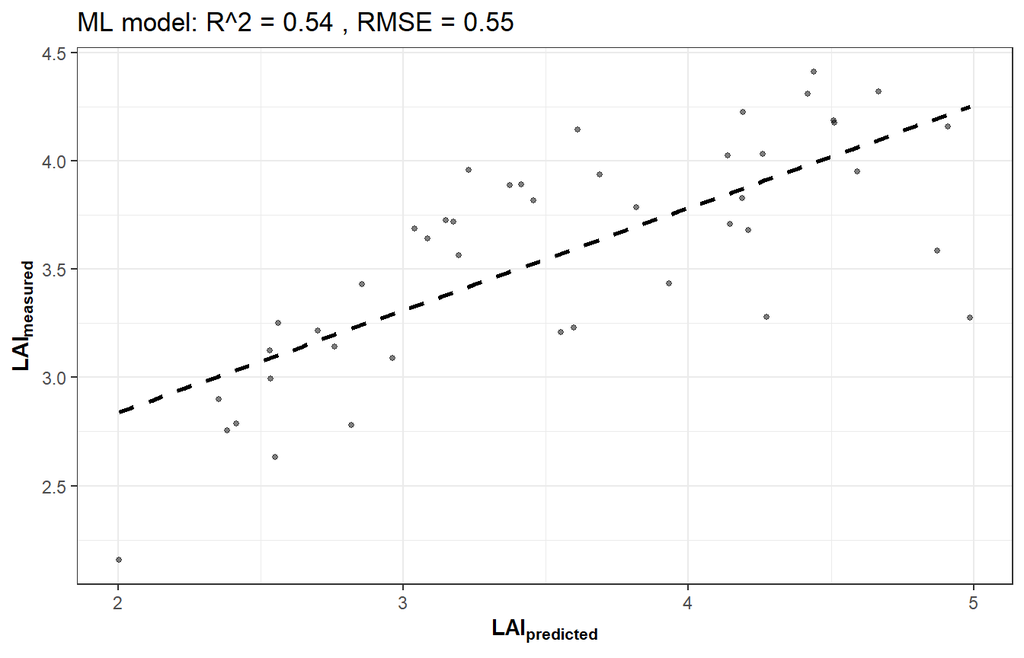

```r
cat("PLSR inversion trained too — same interface, different algorithm underneath.\n")
```

```
## PLSR inversion trained too — same interface, different algorithm underneath.
```

Swap `algorithm = "RF"` for any of the 12 values above — the rest of the call stays identical. What changes is the underlying `caret::train()` method and its accuracy/robustness/interpretability trade-offs, not the interface you use.

# Deep learning (CNN / Hidden-layers via TensorFlow/Keras)

`getMLmodel()` and `getMLmodel_withRetrain()` support real deep learning — `model = "CNN"` (1D convolutional network over the spectrum) or `model = "Hidden-layers"` (a standard dense/MLP network) — built on TensorFlow/Keras, not a “classic ML” method dressed up.

## Setup: Python + TensorFlow + Keras, from R

R’s `library()` alone can’t give you a Python/TensorFlow stack — this is the real, working sequence (run once per machine):

```r
# 1. Install reticulate (R <-> Python bridge) and the R-side keras/tensorflow packages
install.packages(c("reticulate", "keras", "tensorflow"))

# 2. Point reticulate at a real Python 3 installation (adjust for your
#    machine -- e.g. "/usr/bin/python3" on Linux/macOS,
#    "C:/Users/<you>/AppData/Local/Programs/Python/Python312/python.exe" on
#    Windows -- or skip this line entirely and let reticulate auto-provision
#    its own managed Python environment instead, via reticulate::py_config())
library(reticulate)
# use_python("<path to your Python 3>", required = TRUE)

# 3. Install TensorFlow into that Python, plus tf-keras — the classic
#    Keras 2 API that the R keras package expects. Current TensorFlow
#    ships Keras 3 by default, which uses a different calling convention
#    than the R package — tf-keras is the compatibility layer that avoids
#    that mismatch. Run this once, from a terminal (not inside R):
#      pip install tensorflow tf-keras

# 4. Every R session, before calling getMLmodel(): switch on the classic API
Sys.setenv(TF_USE_LEGACY_KERAS = "1")
library(keras)
```

## Running it for real

```r
# NOTE: this chunk needs a working Python + TensorFlow/tf-keras environment
# reachable through reticulate (see the setup section above) -- genuinely
# machine-specific (a hardcoded /usr/bin/python3 path, from wherever this
# manual was first written, would simply be wrong on Windows or any other
# machine without that exact path). Wrapped in tryCatch() so the REST of
# this manual still renders cleanly on a machine without that stack set up,
# while still showing the real, correct calling code below.
dl_result <- tryCatch({
  Sys.setenv(TF_USE_LEGACY_KERAS = "1")
  library(reticulate); library(keras)
  dl_model <- getMLmodel(dataset = train_df, depVar = "LAI", model = "Hidden-layers",
                          optimizer = "adam", n.epochs = 5)
  list(ok = TRUE, model = dl_model)
}, error = function(e) list(ok = FALSE, msg = conditionMessage(e)))
```

```
## [1] "Normalize"
```

[figure not shown]

```r
if (dl_result$ok) {
  cat("Trained. Returned elements:", paste(names(dl_result$model), collapse = ", "), "\n")
  cat("Final training loss:", round(tail(dl_result$model$history$metrics$loss, 1), 3), "\n")
} else {
  # Only the first line of the underlying error is shown -- reticulate's full
  # Python traceback is multi-line raw text that, printed as-is, can break
  # the markdown/HTML this chunk's output gets embedded into (stray lines
  # have been observed turning into spurious empty headings in the rendered
  # HTML). The first line is enough to say *why* it's skipped; the full
  # traceback isn't useful to a tutorial reader anyway.
  first_line <- strsplit(dl_result$msg, "\n", fixed = TRUE)[[1]][1]
  cat("Skipped -- no working Python/TensorFlow/tf-keras stack reachable through",
      "reticulate on this machine (", first_line, "). See the setup section",
      "above for how to configure one; the calling code itself (getMLmodel(...,",
      "model = \"Hidden-layers\")) is correct and unchanged.\n")
}
```

```
## Skipped -- no working Python/TensorFlow/tf-keras stack reachable through reticulate on this machine ( Valid installation of TensorFlow not found. ). See the setup section above for how to configure one; the calling code itself (getMLmodel(..., model = "Hidden-layers")) is correct and unchanged.
```

`optimizer` accepts `"adam"`, `"adadelta"`, `"adagrad"`, `"adamax"`, `"nadam"`, `"rmsprop"`, or `"sgd"`. `model = "CNN"` uses the same interface but reshapes the input for a 1D convolution over the spectrum instead of a plain dense network — swap it in the same call once you have enough training samples for it to be worth the extra complexity (a few hundred simulations at minimum; thousands is more realistic for it to meaningfully beat PLSR/RF).

# What you can customize, in one place

| Want to change… | Where |
| --- | --- |
| Sampling distribution (uniform vs. concentrated) | `get.LUTfromRanges(..., distribution = "uniform"/"gauss")` |
| Trait correlation structure | `getCor(..., rho = ...)` instead of independent `getLUT()` |
| Which leaf/canopy model combination | `simulate_RTM(..., leaf.model = ..., canopy.model = ...)` — see the tables above for what’s really supported |
| Sensor to convolve to | `get.spectra.convolved(..., sensor = "Sentinel2a"/"Sentinel2b"/"PRISMA")` |
| Inversion algorithm | `get.inversion(..., algorithm = ...)` — 12 real options, table above |
| Classic ML vs. deep learning | `get.inversion()` (12 classic algorithms) vs. `getMLmodel()` (CNN/Hidden-layers, needs Python/TensorFlow) |

# Summary

Every code chunk above (except the deep-learning one, which needs an external Python/TensorFlow setup not available in this rendering environment) executed for real while writing this manual.